# Informe Técnico

Juan José Galeano Arenas

Simón Pedro Galeano Muñoz

Sebastian Gaviria Sanchez

Verónica Ríos Vargas

En este informe se muestra el proceso de creación de variables para la construcción del modelo así como hallazgos encontrados para el proceso de modelación.

# Construcción de la base de datos

La base de datos originalmente contaba con dos variables, fecha y unidades (la cual es la variable respuesta). Esta base estaba limpia pues no se encontraron incongruencias, valores faltantes, entre otros.

## Creación de variables

### Variables categóricas

Inicialmente se uso la fecha para crear las variables día, mes, año y semana. Para dicho propósito se usaron las funciones `wday()`, `month`, `year()`, y `week()` de la librería `lubridate`. Dichas funciones fueron aplicadas a la variable fecha, la cual fue transformada previamente en un objeto de la clase date con la función `as.Date()` del paquete `base` de R. Por último se considero la variable festivos la cual se construyó gracias a un repositorio de GitHub (Nequi Colombia 2017) donde se encontró un modulo node.js el cual a través de JavaScript se pudo exportar a un objeto JSON, luego se usó la función `fromJSON()` de la librería `rjson` para poder trabajar con JavaScript Objects Notation (JSON) en R y así extraer los datos de los días festivos en Colombia.

### Variables numéricas

En este caso se consideraron variables numéricas las cuales tienen que ver con el cambio económico del país a lo largo de los años puesto que el aumento o decremento de estas podría afectar el poder adquisitivo de los ciudadanos, dichas variables fueron: PIB anual, PIB persona (Banco de la república, n.d.b), tasa de cambio representativo del mercado del dolar (TRM) (Banco de la república, n.d.d), salario mínimo (Banco de la república, n.d.c), índice de precios al consumidor (IPC) e inflación mensual (Banco de la república, n.d.a). Todas estas variables fueron tomadas de internet de páginas gubernamentales y luego fueron agregadas a la base de datos gracias a diversas funciones de la librería `dplyr` como `inner_join()`, `mutate()`, `filter()`, `select()`, entre otras.

| Fecha | Unidades | Día | Mes | Año | Semana | Festivo | PIB anual | PIB persona | TRM | Salario mínimo | IPC | Inflación mensual |
| --- | --- | --- | --- | --- | --- | --- | --- | --- | --- | --- | --- | --- |
| 2012-01-01 | 0 | dom | ene | 2012 | 1 | Si | 3.912636 | 2.943729 | 1942.70 | 566700 | 76.75 | 0.73 |
| 2012-01-02 | 188 | lun | ene | 2012 | 1 | No | 3.912636 | 2.943729 | 1942.70 | 566700 | 76.75 | 0.73 |
| 2012-01-03 | 482 | mar | ene | 2012 | 1 | No | 3.912636 | 2.943729 | 1942.70 | 566700 | 76.75 | 0.73 |
| 2012-01-04 | 927 | mié | ene | 2012 | 1 | No | 3.912636 | 2.943729 | 1915.02 | 566700 | 76.75 | 0.73 |
| 2012-01-05 | 1159 | jue | ene | 2012 | 1 | No | 3.912636 | 2.943729 | 1898.24 | 566700 | 76.75 | 0.73 |
| 2012-01-06 | 996 | vie | ene | 2012 | 1 | No | 3.912636 | 2.943729 | 1884.44 | 566700 | 76.75 | 0.73 |

# Análisis descriptivo

En esta sección se presentan diversos gráficos para detectar posibles relaciones entre las covariables y la respuesta.

### Distribución del número global de vehículos registrados en los distintos días de la semana

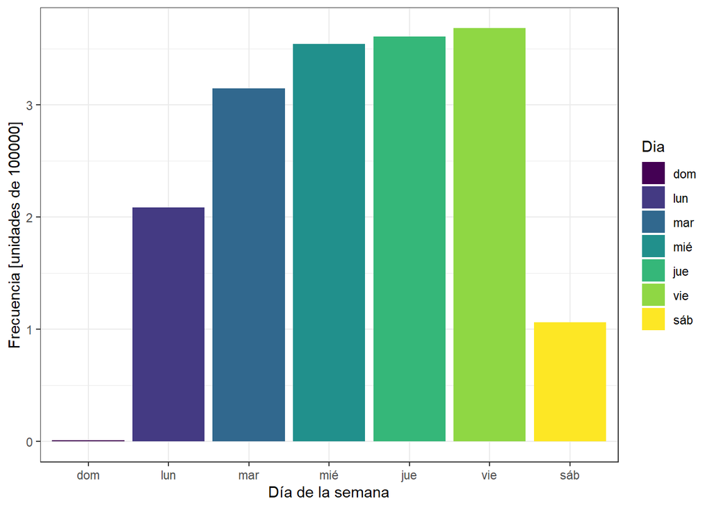

Unidades registradas en cada día de la semana (global)

### Distribución del número de vehiculos registrados en los distintos días de la semana discriminando por año

El análisis previo se desarrollo de manera global, sin embargo, surge la duda de si dicho comportamiento cambia en los distintos años o se mantiene igual

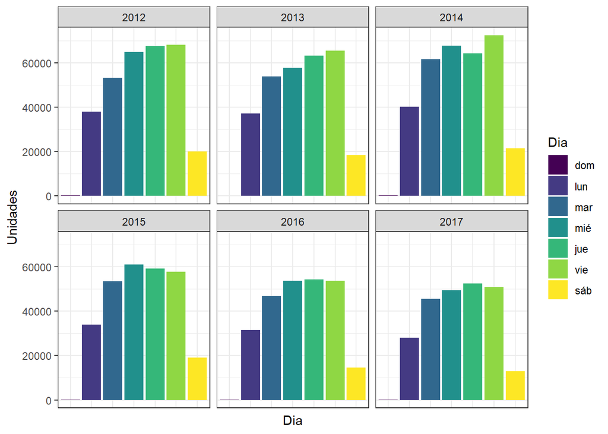

Unidades registradas en cada día de la semana (anual)

Observe que el número de registros por día se distribuye de forma similar a lo largo de los años, también se aprecia que a medida que avanzan los años el número de registros es menor lo cual sugiere que existen fenómenos que han afectado el poder adquisitivo de las personas.

### Correlación lineal entre variables numéricas

La correlación lineal interesa por dos principales razones

- Observar si un modelo lineal es útil para predecir el número de vehículos registrados un día particular.
- Evitar potenciales problemas de multicolinealidad entre producido por covariables que estén muy correlacionadas.

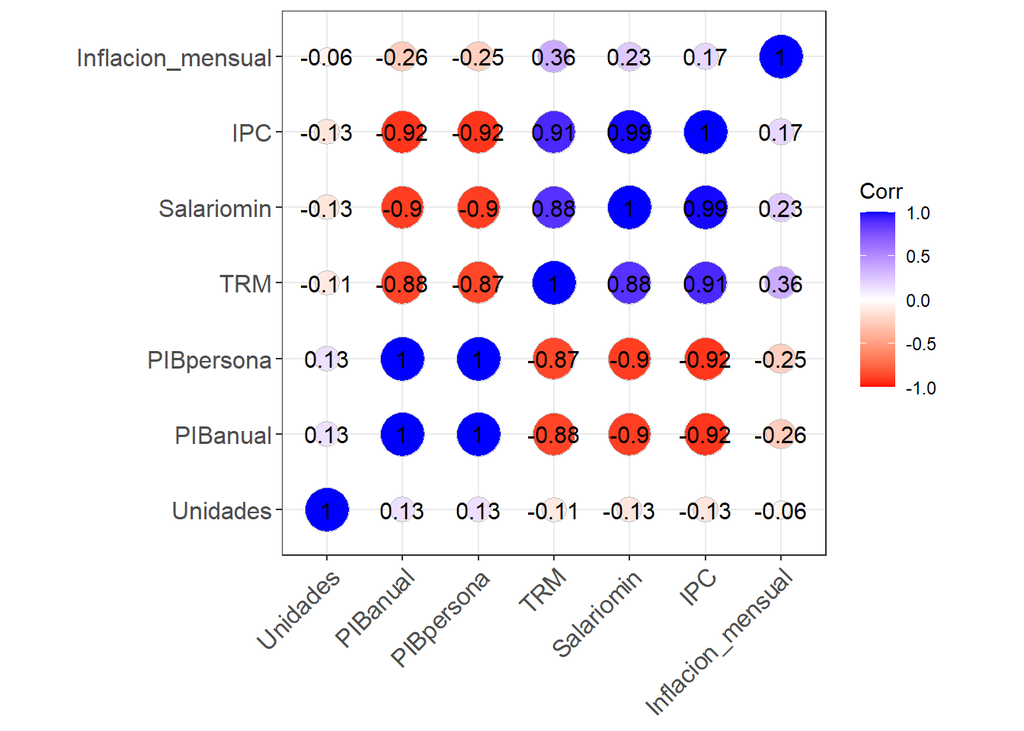

Correlación lineal entre variables numéricas

Note que la correlación lineal entre la variable respuesta y cada una de las covariables es muy baja por lo que un modelo lineal usando los regresores crudos puede no ser adecuado. Por otro lado, a excepción de la inflación mensual, los predictores están muy correlacionados linealmente y por lo tanto provocar potentes problemas de multicolinealidad, luego en caso de usar variables numéricas en modelos sensibles a la multicolinealidad se debería tomar únicamente una de estas.

### Diagramas de dispersión para Unidades vs regresores

Puesto que las correlaciones lineales son muy bajas, se grafican diagramas de dispersión con el propósito de hallar posibles relaciones de otro tipo entre el número de registros de vehículos diarios y las variables predictoras numéricas

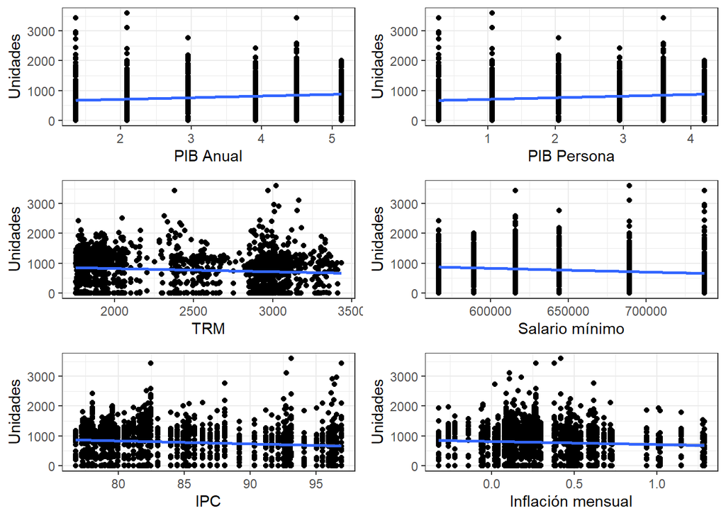

Diagramas de dispersión

En ningún caso se logra detectar algún tipo de relación funcional entre las covariables y la respuesta lo cual sugiere que estas variables pueden no ser útiles para el proceso de modelación.

# Bibliografía

Banco de la república. n.d.a. “Índice de Precio Al Consumidor (IPC),” https://www.banrep.gov.co/es/estadisticas/indice-precios-consumidor-ipc.

———. n.d.b. “Producto Interno Bruto (PIB).” https://www.banrep.gov.co/es/estadisticas/producto-interno-bruto-pib.

———. n.d.c. “Salarios.” https://www.banrep.gov.co/es/estadisticas/salarios.

———. n.d.d. “Tasa Representativa Del Mercado.” https://www.banrep.gov.co/es/estadisticas/trm.

Nequi Colombia. 2017. “Colombia Holidays.” 2017. https://github.com/nequibc/colombia-holidays.